# White and Red Wine EDA by Mithil Viradia

```r
library(ggplot2)
library(GGally)


wineWhite = read.csv('wineQuality-White.csv',sep = ';')
wineRed = read.csv('wineQuality-red.csv', sep = ';')

#made a new categorical variable, color
wineWhite['color'] = 'white'
wineRed['color'] = 'red'

#combine both the White wind and Red wine datasets
df = rbind(wineRed,wineWhite)

#set the ggplot grid style
my_style = theme_bw() + theme(panel.border = element_blank(), panel.grid.major = element_blank())
```

http://winefolly.com/review/sugar-in-wine-chart/

http://www.winespectator.com/drvinny/show/id/5035

# About the Data Set

Both of the data sets have the same variables

- Fixed Acidity(g/dm^3) - measure of tartic acid, having low acidity will result in a flat taste whereas too much will result in tartness. So, the plot for quailty vs Fixed Acidity should be a bell curve.
- Volatile Acidity(g/dm^3) - meaure of acetic acid, produced through microbial action so too much will lead to spoilage. Wine makers try to make supress volatile acidity as much as they can.
- Citric Acid(g/dm^3) - small amounts lead to nice tangy, and fresh taste.
- Residual Sugar(g/dm^3) - amount of sugar left, <6 g/dm^3 will lead to a dry taste and >21 g/dm^3 will lead to a sweet taste
- Chlorides(g/dm^3) - salt in wine
- Free Sulfur Dioxide(mg/dm^3) - prevents microbial growth/oxidation, I think that Votatile Acidity and Free Sulfur Dioxide will have an inverse realtionship beacuse since volatile acidity is produced through microbes and SO2 prevents microbial activity
- Total Sulfur Dioxide(mg/dm^3) - amount of free and bound SO2
- Density(g/cm^3) - %sugar to %alcohol, high sugar leads to higher density, high alcohol leads to lower density
- pH(1-14) - used to measure ripeness to acidity, most wines will have a pH from 3 to 4. So, the best whites will have pH(3-3.4) whereas best reds will have pH(3.3-3.6). Low pH will lead to a tart taste while high pH will lead to a bacterial growth.
- Sulphates(g/dm^3) - acts as a microbial deterrent
- Alcohol(% by volume) - % alcohol, measure of how much the fermentation has completed
- Quality(0-10) - the output, wine tasters gave a score of 0 - 10

```r
dim(df)
```

```
## [1] 6497   13
```

```r
summary(df)
```

```
##  fixed.acidity    volatile.acidity  citric.acid     residual.sugar
##  Min.   : 3.800   Min.   :0.0800   Min.   :0.0000   Min.   : 0.600
##  1st Qu.: 6.400   1st Qu.:0.2300   1st Qu.:0.2500   1st Qu.: 1.800
##  Median : 7.000   Median :0.2900   Median :0.3100   Median : 3.000
##  Mean   : 7.215   Mean   :0.3397   Mean   :0.3186   Mean   : 5.443
##  3rd Qu.: 7.700   3rd Qu.:0.4000   3rd Qu.:0.3900   3rd Qu.: 8.100
##  Max.   :15.900   Max.   :1.5800   Max.   :1.6600   Max.   :65.800
##    chlorides       free.sulfur.dioxide total.sulfur.dioxide
##  Min.   :0.00900   Min.   :  1.00      Min.   :  6.0
##  1st Qu.:0.03800   1st Qu.: 17.00      1st Qu.: 77.0
##  Median :0.04700   Median : 29.00      Median :118.0
##  Mean   :0.05603   Mean   : 30.53      Mean   :115.7
##  3rd Qu.:0.06500   3rd Qu.: 41.00      3rd Qu.:156.0
##  Max.   :0.61100   Max.   :289.00      Max.   :440.0
##     density             pH          sulphates         alcohol
##  Min.   :0.9871   Min.   :2.720   Min.   :0.2200   Min.   : 8.00
##  1st Qu.:0.9923   1st Qu.:3.110   1st Qu.:0.4300   1st Qu.: 9.50
##  Median :0.9949   Median :3.210   Median :0.5100   Median :10.30
##  Mean   :0.9947   Mean   :3.219   Mean   :0.5313   Mean   :10.49
##  3rd Qu.:0.9970   3rd Qu.:3.320   3rd Qu.:0.6000   3rd Qu.:11.30
##  Max.   :1.0390   Max.   :4.010   Max.   :2.0000   Max.   :14.90
##     quality         color
##  Min.   :3.000   Length:6497
##  1st Qu.:5.000   Class :character
##  Median :6.000   Mode  :character
##  Mean   :5.818
##  3rd Qu.:6.000
##  Max.   :9.000
```

# Observations from the Summary

- Residual Sugar has a huge outlier. The 3rd quantile is at 8.1 while the max is at 65.8. I think it can be split into groups of sweetness.
- pH has a small range. All of it is contained withn 2.720 and 4.010.
- Quality has 50% of its data withn 5 and 6 so it should look a nice bell curve.
- Sulphates, Total SO2, Free SO2, Fixed acidity, Volatile acidity, and Citric acidity have maxes which are atleast double the 3rd quantile.

# Single Variable Analysis

Lets look at the frequenct of single variables

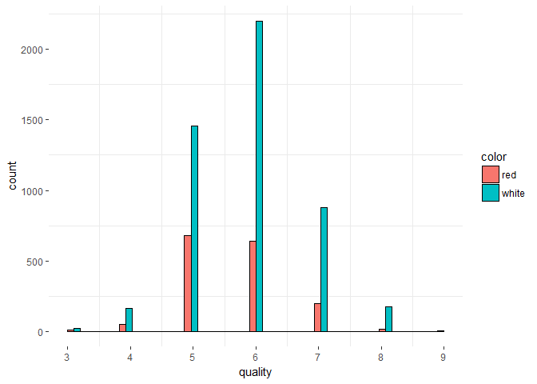

```r
ggplot(aes(x= quality, fill = color), data = df) + geom_histogram(colour= 'black', position = position_dodge()) + scale_x_continuous(breaks = seq(3,9,1)) + my_style
```

- Most of the data comes from White wines. Also, the values of quality are mainly 5,6, or 7. The plot looks like a normal curve.

```r
by(df$pH, df$color, summary)
```

```
## df$color: red
##    Min. 1st Qu.  Median    Mean 3rd Qu.    Max.
##   2.740   3.210   3.310   3.311   3.400   4.010
## --------------------------------------------------------
## df$color: white
##    Min. 1st Qu.  Median    Mean 3rd Qu.    Max.
##   2.720   3.090   3.180   3.188   3.280   3.820
```

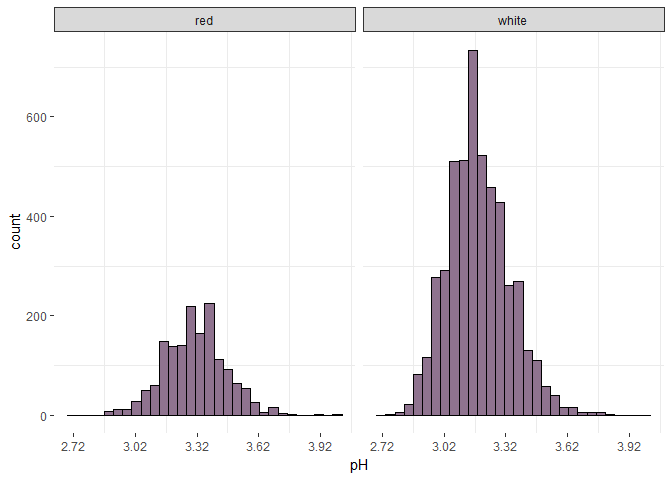

```r
ggplot(aes(x = pH), data = df) + geom_histogram(colour = 'black', fill = I('#8F738F')) + facet_wrap(~color) + scale_x_continuous(breaks = seq(min(df$pH), max(df$pH),.3)) + my_style
```

- pH has a normal curve look to it. For the reds, most of the data is between 3.2 and 3.4. For the whites, most of the data is between 3.09 and 3.28.

```r
by(df$density, df$color, summary)
```

```
## df$color: red
##    Min. 1st Qu.  Median    Mean 3rd Qu.    Max.
##  0.9901  0.9956  0.9968  0.9967  0.9978  1.0037
## --------------------------------------------------------
## df$color: white
##    Min. 1st Qu.  Median    Mean 3rd Qu.    Max.
##  0.9871  0.9917  0.9937  0.9940  0.9961  1.0390
```

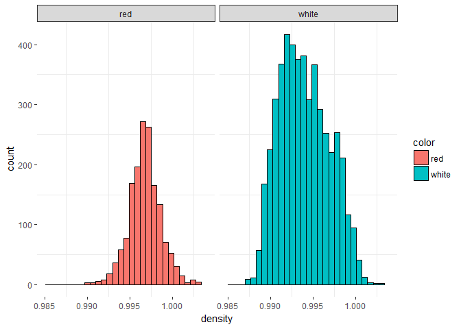

```r
ggplot(aes(x = density, fill = color), data = df) + geom_histogram(colour = 'black') + scale_x_continuous(lim = c(.985,1.004)) + facet_wrap(~color) + my_style
```

- From this plot, it can seen that most of the density values are lower than 1. This means that most of the wine was fermented because higher % alcohol leads to lower density. I chose not to include the outliers because they made the distribution of data not as clear. I can be seen that the density for the red wine looks to have a normal curve distribution.

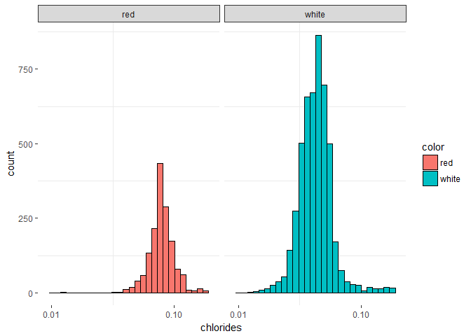

```r
ggplot(aes(x = chlorides, fill = color), data = df) + geom_histogram(colour = 'black') + scale_x_log10(lim = c(min(df$chlorides),.2)) + facet_wrap(~color) + my_style
```

- Here it can be seen that both of the plots have a nice unimodal distribution. This is because I transformed the x-axis to log10 scale otherwise the two plots had an unclear distribution pattern.

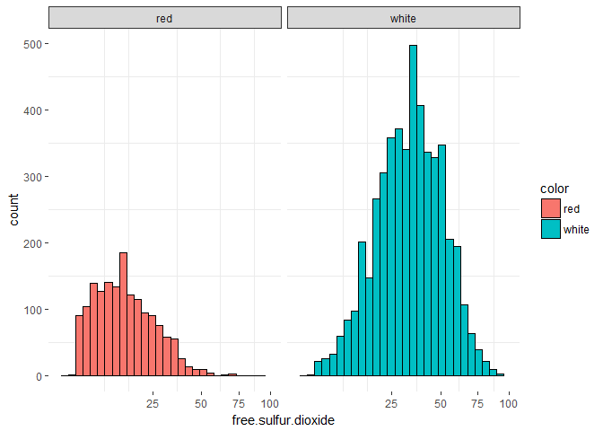

```r
ggplot(aes(x = free.sulfur.dioxide, fill = color), data = df) + geom_histogram(colour = 'black') + facet_wrap(~color) + scale_x_sqrt(lim = c(min(df$free.sulfur.dioxide),100)) + my_style
```

- The red wines have a right skewed plot whereas the white wines have a left skewed plot. I transformed the sacle to sqrt beacuse the distribution is most clear on this scale.

### What are the main features of interest in your dataset?

PH, density, and acid levels will the most effect on quailty. I also suspect that sulphates and volatile acidity are most likely realated.

### What other features do you think will help in your investigation?

Any measurement of sulfur and acid levels will be really important in building a predictive model for quailty.

### Did you make any new variables?

I used the categorical variable ‘color’ to analyze other variable differences between red and white wine.

### Was there anything strange about any of the features you investigated?

Sqrt and log10 transformations for chlorides and free SO2 was a bit strange. Maybe, those transformations will play a role in the predective model.

# Bivariate and Multivariate Anaylsis

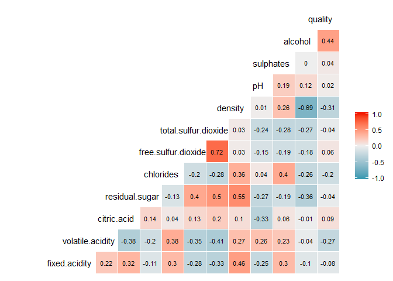

```r
library(GGally)
ggcorr(df, label = TRUE, label_round = 2, label_size = 3, layout.exp = 3, hjust = .84) + my_style ##remove the X or id variable
```

### Observations about the Correlation Matrix

- Total sulfur dioxide and free sulfur dioxide has the highest correlation magnitude with .72
- As I stated earlier, votatile acidity and free/total sulfur dioxide have an inverse realtionship with magnitude -.35 and -.41, respectively
- Alcohol, density, and volatile acidity have the most impact on quality
- Density is highly tied to alcohol and residual sugars which supports the data despriction
- It is odd that free/total sulfur dioxide has a negative realtionship with sulphates
- The matrix suggests pH doesn’t have a high impact on quality but the data is mostly centered around 3 and 4 so its difficult to tell which pH level will have an impact
- I belive that this matrix plot is sufficent enough to explain what is going on at the two dimensional level

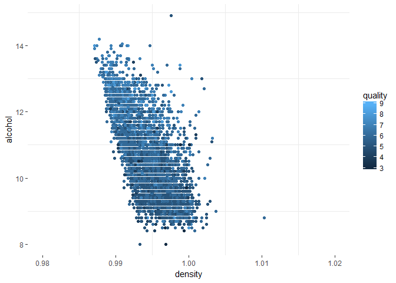

```r
ggplot(aes(x = density, y = alcohol, color = quality), data = df) + geom_point() + scale_x_continuous(limits = c(.98,1.02)) + my_style
```

- This plot compares desnity with alcohol based on quality. It is hard to distiguish a pattern from this plot. This means that the qulity factor needs to be narrowed down so we can if there is a pattern.

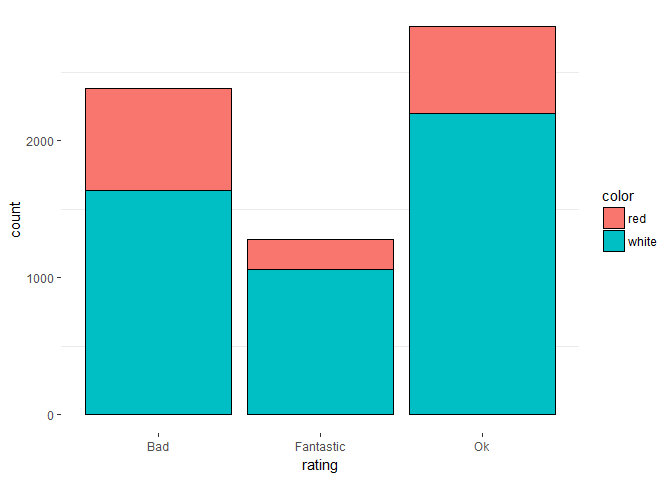

```r
df$rating[5< df$quality & df$quality < 7] = 'Ok'
df$rating[5 >= df$quality] = 'Bad'
df$rating[df$quality >= 7] = 'Fantastic'

df$ratingsep[5>= df$quality] = 'Bad'
df$ratingsep[df$quality >= 7] = 'Fantastic'

ggplot(aes(x = rating, fill = color), data = df) + geom_bar(colour = 'black') + my_style
```

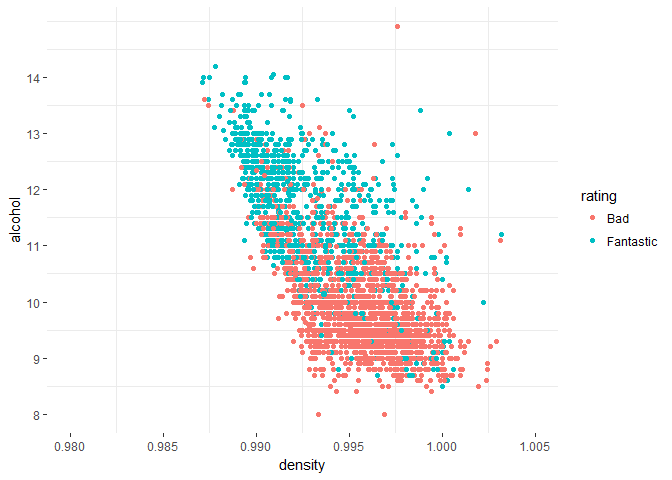

```r
ggplot(aes(y = alcohol, x  = density, color = rating), data = subset(df, rating %in% c('Bad' , 'Fantastic'))) + geom_point() + scale_x_continuous(limits = c(.98,1.005))  + scale_y_continuous(breaks = seq(8,14,1)) + my_style ##made limit .98 to 1.005 beacuse that is where most of the data is centered
```

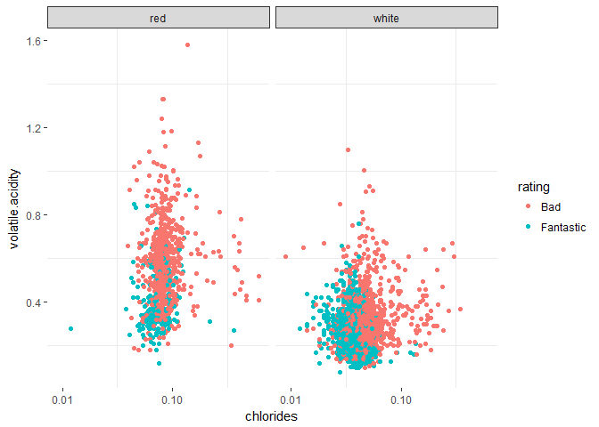

```r
ggplot(aes(y = volatile.acidity, x = chlorides, color = rating), data = subset(df, rating %in% c('Bad' , 'Fantastic')))+ geom_point() + scale_x_log10() + facet_wrap(~color) + my_style
```

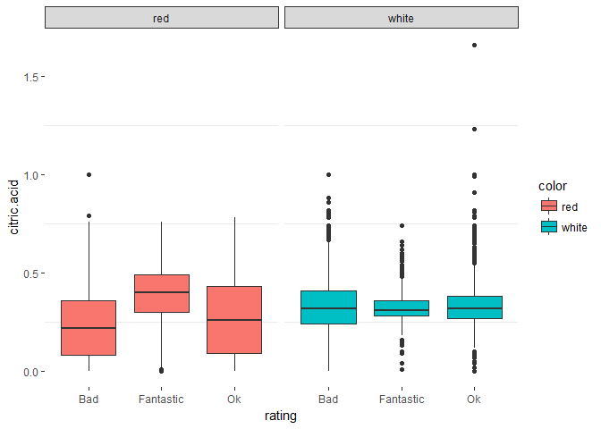

```r
ggplot(aes(x = rating, y = citric.acid, fill = color), data = df) + geom_boxplot() + facet_wrap(~color) + my_style
```

- This plot shows citric acid levels for diffrent ratings seprated by wine color. White wines have about the same median and iqr for citric acid. Whereas, with the red wines, it is obvious to see that citric acid levels seprate ‘Bad’ and ‘Fantastic’ wine very clearly.

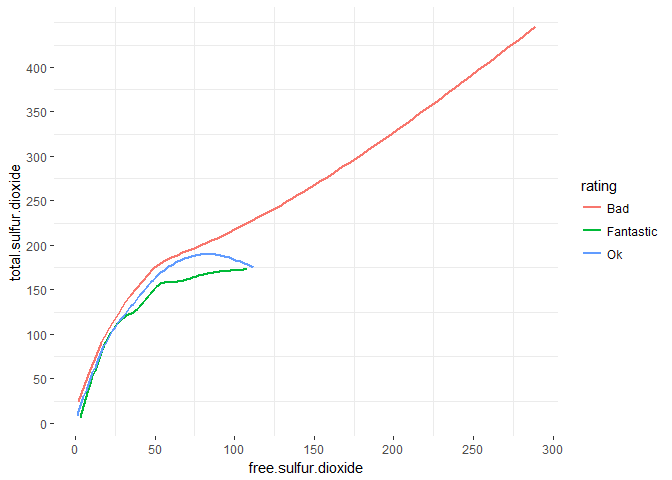

```r
ggplot(aes(x = free.sulfur.dioxide, y = total.sulfur.dioxide, color = rating), data = df) + geom_smooth(se = FALSE) + scale_x_continuous(breaks = seq(0,300, 50)) + scale_y_continuous(breaks = seq(0,400,50)) + my_style
```